# Analysis of genomic and ploidy alterations in breast tumors

# 2.Network reconstruction with the PC approach

```r
library("miic")
library("bnlearn")
library("janitor")
library("igraph")
library("qgraph")
library("pcalg")
```

```r
Data=cosmicCancer
View(cosmicCancer)
```

```r
head(cosmicCancer)
```

|  | bbc3 | egln1 | tgfb3 | esm1 | igfbp5 | fgf18 | scube2 | wisp1 | flt1 | hrasls | stk32b | rassf7 | dck | melk | ext1 | gnaz | ebf4 | mtdh | pitrm1 | qscn6l1 | ccne2 | ect2 | cenpa | lin9 | kntc2 | mcm6 | nusap1 | orc6l | tspyl5 | … |
| --- | --- | --- | --- | --- | --- | --- | --- | --- | --- | --- | --- | --- | --- | --- | --- | --- | --- | --- | --- | --- | --- | --- | --- | --- | --- | --- | --- | --- | --- | --- |
| 1 | n | n | n | n | n | n | n | n | n | n | n | n | n | n | n | n | n | n | n | n | n | n | n | n | n | n | n | n | n | … |
| 2 | n | n | n | n | n | n | n | n | n | n | n | n | n | n | n | n | n | n | n | n | n | n | n | n | n | n | n | n | n | … |
| 3 | n | n | n | n | n | n | n | n | n | n | n | n | n | n | n | n | n | n | n | n | n | n | n | n | n | n | n | n | n | … |
| 4 | n | n | n | n | n | n | n | n | n | n | n | n | n | n | n | n | n | n | n | n | n | n | n | n | n | n | n | n | n | … |
| 5 | n | n | n | n | n | n | n | n | n | n | n | n | n | n | n | n | n | n | n | n | n | n | n | n | n | n | n | n | n | … |
| 6 | n | n | n | n | n | n | n | n | n | n | n | n | n | n | n | n | n | n | n | n | n | n | n | n | n | n | n | n | n | … |

```r
dim(cosmicCancer)
```

```
[1] 807 176
```

```r
colnames(cosmicCancer)
```

```
  [1] "bbc3"     "egln1"    "tgfb3"    "esm1"     "igfbp5"   "fgf18"    "scube2"   "wisp1"    "flt1"     "hrasls"   "stk32b"   "rassf7"   "dck"      "melk"
 [15] "ext1"     "gnaz"     "ebf4"     "mtdh"     "pitrm1"   "qscn6l1"  "ccne2"    "ect2"     "cenpa"    "lin9"     "kntc2"    "mcm6"     "nusap1"   "orc6l"
 [29] "tspyl5"   "rundc1"   "prc1"     "rfc4"     "recql5"   "cdca7"    "dtl"      "col4a2"   "gpr180"   "mmp9"     "gpr126"   "rtn4rl1"  "diaph3"   "cdc42bpa"
 [43] "palm2"    "aldh4a1"  "aytl2"    "oxct1"    "peci"     "gmps"     "gstm3"    "slc2a3"   "foxm1"    "erbb2"    "esr1"     "tp53"     "rb1"      "myc"
 [57] "jun"      "cdkn2a"   "bcl2"     "tp73"     "lats2"    "mapk14"   "cdkn1a"   "chek1"    "aurkb"    "aurka"    "brca1"    "brca2"    "dusp5"    "mst1"
 [71] "ppp1r13l" "birc3"    "tgfa"     "ets1"     "ets2"     "hif1a"    "ldha"     "foxo1"    "ndrg1"    "ppp2r1a"  "ppp2r2a"  "ccne1"    "apobec3b" "pten"
 [85] "mdm2"     "usp7"     "ube3a"    "spdye7p"  "plk1"     "bax"      "met"      "BBC3"     "EGLN1"    "TGFB3"    "ESM1"     "IGFBP5"   "FGF18"    "SCUBE2"
 [99] "WISP1"    "FLT1"     "HRASLS"   "STK32B"   "RASSF7"   "DCK"      "MELK"     "EXT1"     "GNAZ"     "MTDH"     "PITRM1"   "CCNE2"    "ECT2"     "CENPA"
[113] "LIN9"     "MCM6"     "NUSAP1"   "TSPYL5"   "RUNDC1"   "PRC1"     "RFC4"     "RECQL5"   "CDCA7"    "DTL"      "COL4A2"   "GPR180"   "MMP9"     "GPR126"
[127] "RTN4RL1"  "DIAPH3"   "CDC42BPA" "PALM2"    "ALDH4A1"  "OXCT1"    "GMPS"     "GSTM3"    "SLC2A3"   "ERBB2"    "ESR1"     "TP53"     "RB1"      "MYC"
[141] "JUN"      "CDKN2A"   "BCL2"     "FOXM1"    "BRCA1"    "TP73"     "LATS2"    "MAPK14"   "CDKN1A"   "CHEK1"    "BRCA2"    "AURKB"    "AURKA"    "APOBEC3B"
[155] "DUSP5"    "MST1"     "PPP1R13L" "BIRC3"    "TGFA"     "ETS1"     "ETS2"     "HIF1A"    "LDHA"     "FOXO1"    "NDRG1"    "PPP2R1A"  "PPP2R2A"  "CCNE1"
[169] "PTEN"     "MDM2"     "USP7"     "UBE3A"    "PLK1"     "BAX"      "MET"      "Ploidy"
```

```r
cosmicCancer_data = data.matrix(cosmicCancer)
cosmicCancer_data= cosmicCancer_data -1
n_lev = rep(-1, ncol(cosmicCancer_data))
for(iCol in 1:length(n_lev)){
  n_lev[iCol] = length(unique(cosmicCancer_data[,iCol]))
}

suffStat <- list(dm = cosmicCancer_data, nlev = n_lev, adaptDF = FALSE)
```

```r
res_pc.cosmicCancer <- pc(suffStat,indepTest = disCItest, p = ncol(cosmicCancer_data), alpha = 0.01,verbose = TRUE)
```

```
Order=0; remaining edges:30800
```

```
Error in if (any(as.integer(dm) != dm)) stop("'dm' must be discrete, with values in {0,1,..}") :
  missing value where TRUE/FALSE needed
```

## Q2

- 1. Les données ne sont pas continues dans le dataset donc on ne peut pas appliquer PC directement sur ce dataset.

```r
##Cleaning data
#Missing value
sum(is.na(cosmicCancer)) # sommer le nombre des éléments NA dans le dataset
```

```
[1] 8
```

```r
summary(cosmicCancer)
```

```
 bbc3    egln1   tgfb3   esm1    igfbp5  fgf18   scube2  wisp1   flt1    hrasls  stk32b  rassf7  dck     melk    ext1    gnaz    ebf4    mtdh    pitrm1  qscn6l1
 n:806   n:804   n:804   n:807   n:805   n:802   n:800   n:801   n:799   n:806   n:802   n:806   n:805   n:802   n:800   n:801   n:807   n:806   n:798   n:807
 y:  1   y:  3   y:  3           y:  2   y:  5   y:  7   y:  6   y:  8   y:  1   y:  5   y:  1   y:  2   y:  5   y:  7   y:  6           y:  1   y:  9

 ccne2   ect2    cenpa   lin9    kntc2   mcm6    nusap1  orc6l   tspyl5  rundc1  prc1    rfc4    recql5  cdca7   dtl     col4a2  gpr180  mmp9    gpr126  rtn4rl1
 n:802   n:801   n:807   n:802   n:807   n:801   n:803   n:807   n:805   n:803   n:803   n:802   n:798   n:803   n:804   n:797   n:804   n:800   n:799   n:805
 y:  5   y:  6           y:  5           y:  6   y:  4           y:  2   y:  4   y:  4   y:  5   y:  9   y:  4   y:  3   y: 10   y:  3   y:  7   y:  8   y:  2

 diaph3  cdc42bpa palm2   aldh4a1 aytl2   oxct1   peci    gmps    gstm3   slc2a3  foxm1   erbb2   esr1    tp53    rb1     myc     jun     cdkn2a  bcl2    tp73
 n:800   n:791    n:803   n:806   n:807   n:806   n:807   n:804   n:806   n:804   n:800   n:786   n:800   n:520   n:783   n:804   n:804   n:807   n:805   n:804
 y:  7   y: 16    y:  4   y:  1           y:  1           y:  3   y:  1   y:  3   y:  7   y: 21   y:  7   y:287   y: 24   y:  3   y:  3           y:  2   y:  3

 lats2   mapk14  cdkn1a  chek1   aurkb   aurka   brca1   brca2   dusp5   mst1    ppp1r13l birc3   tgfa    ets1    ets2    hif1a   ldha    foxo1   ndrg1   ppp2r1a
 n:805   n:805   n:807   n:804   n:803   n:804   n:787   n:781   n:806   n:805   n:803    n:806   n:806   n:799   n:800   n:801   n:804   n:807   n:801   n:801
 y:  2   y:  2           y:  3   y:  4   y:  3   y: 20   y: 26   y:  1   y:  2   y:  4    y:  1   y:  1   y:  8   y:  7   y:  6   y:  3           y:  6   y:  6

 ppp2r2a ccne1   apobec3b pten    mdm2    usp7    ube3a   spdye7p plk1    bax     met         BBC3        EGLN1        TGFB3         ESM1        IGFBP5
 n:807   n:803   n:805    n:759   n:801   n:802   n:803   n:807   n:803   n:791   n:796   normal:803   normal:638   normal:784   normal:751   normal:771
         y:  4   y:  2    y: 48   y:  6   y:  5   y:  4           y:  4   y: 16   y: 11   over  :  4   over  :161   over  : 23   over  : 56   over  : 36
                                                                                                       under :  8
    FGF18        SCUBE2       WISP1         FLT1        HRASLS       STK32B       RASSF7        DCK          MELK         EXT1         GNAZ         MTDH
 normal:776   normal:780   normal:802   normal:781   normal:737   normal:786   normal:805   normal:752   normal:714   normal:740   normal:762   normal:511
 over  : 31   over  : 27   over  :  5   over  : 26   over  : 70   over  : 21   over  :  2   over  : 55   over  : 93   over  : 67   over  : 45   over  :296

    PITRM1       CCNE2         ECT2        CENPA         LIN9         MCM6        NUSAP1       TSPYL5       RUNDC1        PRC1         RFC4        RECQL5
 normal:689   normal:673   normal:688   normal:706   normal:688   normal:736   normal:735   normal:633   normal:745   normal:693   normal:679   normal:750
 over  :117   over  :134   over  :119   over  :101   over  :119   over  : 71   over  : 72   over  :174   over  : 38   over  :114   over  :128   over  : 56
 under :  1                                                                                              under : 24                             under :  1
    CDCA7         DTL         COL4A2       GPR180        MMP9        GPR126      RTN4RL1       DIAPH3      CDC42BPA      PALM2       ALDH4A1       OXCT1
 normal:724   normal:795   normal:786   normal:721   normal:805   normal:734   normal:792   normal:728   normal:682   normal:746   normal:781   normal:740
 over  : 83   over  : 12   over  : 21   over  : 86   over  :  2   over  : 73   over  : 15   over  : 79   over  :125   over  : 61   over  : 26   over  : 67

```

[output cut: 16 more lines]

```r
dataCleaned<- cosmicCancer[complete.cases(cosmicCancer), ]
dim(dataCleaned)
```

```
[1] 799 176
```

```r
same <- sapply(dataCleaned, function(.col){ all(.col[1L] == .col)})
dataCleaned <- dataCleaned[!same]
dim(dataCleaned)
```

```
[1] 799 162
```

```r
#Gerer la varaible 'Ploidy'
dataCleaned[,"Ploidy"]=as.factor(dataCleaned[,"Ploidy"])
class(dataCleaned[,"Ploidy"])
```

```
[1] "factor"
```

```r
levels(dataCleaned[,"Ploidy"])
```

```
[1] "1" "2"
```

```r
dim(cosmicCancer)
```

```
[1] 807 176
```

```r
dim(dataCleaned)
```

```
[1] 799 162
```

## Q3

- 2. Nous avons enlevé 8 observations après nettoyage des données et avons supprimé 14 varaibles par rapport au dataset initial.

```r
data_pc=data.matrix(dataCleaned)
data_pc=data_pc-1
nlevels=apply(data_pc,2,function(x) length(attr(as.factor(x), "levels")))
suffStat=list(dm = data_pc, nlev=nlevels, adaptDF = FALSE)
```

```r
pc_model <- pc(suffStat, indepTest=disCItest, alpha=0.01, labels=colnames(data_pc))
```

```r
pc_model
```

```
Object of class 'pcAlgo', from Call:
pc(suffStat = suffStat, indepTest = disCItest, alpha = 0.01,
    labels = colnames(data_pc))
Number of undirected edges:  12
Number of directed edges:    45
Total number of edges:       57
```

```r
pc<-as.bn(pc_model, check.cycles = FALSE)
adj_pc<-amat(pc)
graph_pc = graph_from_adjacency_matrix(adj_pc)
```

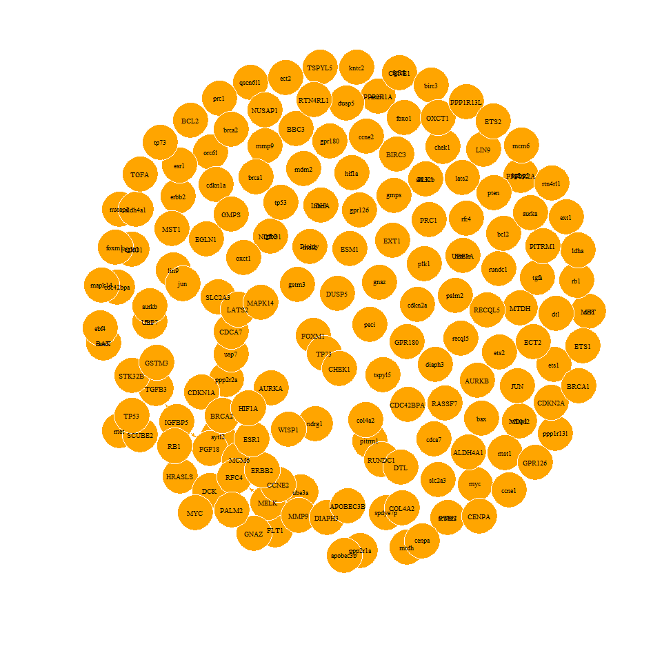

```r
### affichage du graphe (net) obtenu après application de pc et sans isolation
plot(graph_pc, edge.arrow.size = .3,
     edge.color = "orange", vertex.color = "orange",
     vertex.frame.color ="#FFFFFF",
     vertex.label.color = "black", vertex.label.cex = .6,
     vertex.label = colnames(cosmicCancer_data),
     layout = layout.fruchterman.reingold)
```

## Q4

```r
Isolated = which(igraph::degree(graph_pc)==0)
graph_pc_I = delete.vertices(graph_pc, Isolated)
```

```r
library(qgraph)
e <- get.edgelist(graph_pc_I,names=FALSE)
l <- qgraph.layout.fruchtermanreingold(e,vcount=vcount(graph_pc_I),
                                      area=8*(vcount(graph_pc_I)^2),repulse.rad=(vcount(graph_pc_I)^3.1))

colors = rep("cyan3", length(V(graph_pc_I)))
colors[names(V(graph_pc_I)) == tolower(names(V(graph_pc_I)))] = "chartreuse3"
colors[names(V(graph_pc_I)) == "Ploidy"] = "brown3"
```

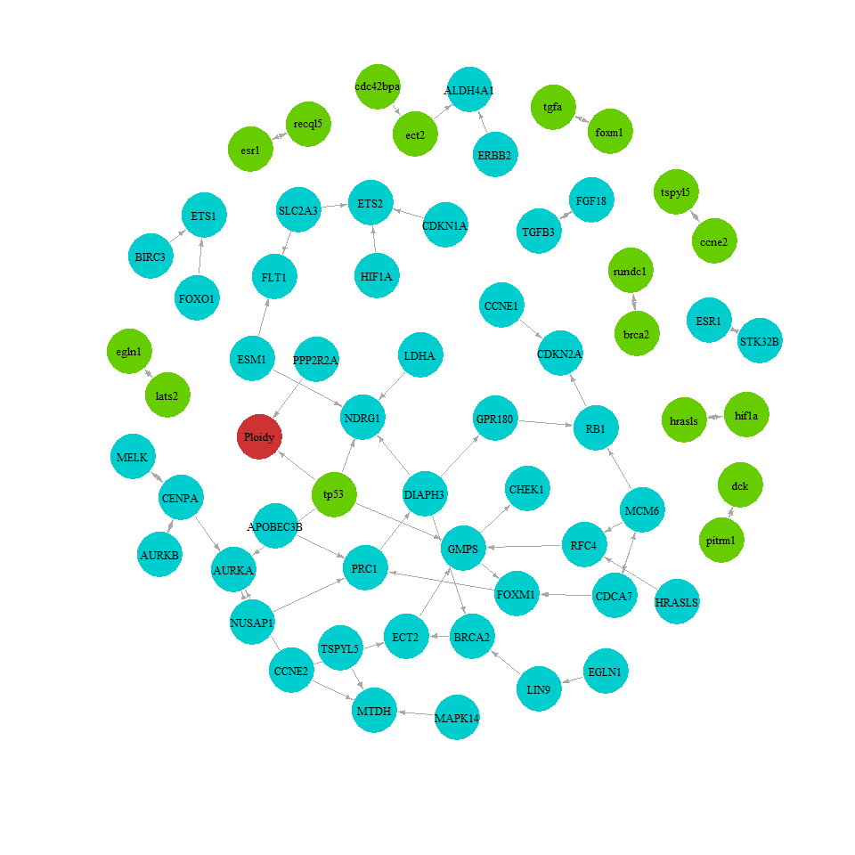

```r
### affichage du graphe  obtenu après application de pc avec isolation et  une coloration des noeuds

plot(graph_pc_I,
     vertex.color=colors,
     edge.arrow.size = .4,
     vertex.frame.color ="#ffffff",
     vertex.label.color = "black", vertex.label.cex = .8,
     layout =l)
```

Nous remarquons que la variable Ploidy est affectée par tp35 et PPP2R2A. Elle n’affecte aucune varaible.

## Q5

- Alpha = 0.001

```r
data_pc=data.matrix(dataCleaned)
data_pc=data_pc-1
nlevels=apply(data_pc,2,function(x) length(attr(as.factor(x), "levels")))
suffStat=list(dm = data_pc, nlev=nlevels, adaptDF = FALSE)
```

```r
pc_model_001 <- pc(suffStat, indepTest=disCItest, alpha=0.001, labels=colnames(data_pc))
```

```r
pc_model_001
```

```
Object of class 'pcAlgo', from Call:
pc(suffStat = suffStat, indepTest = disCItest, alpha = 0.001,
    labels = colnames(data_pc))
Number of undirected edges:  12
Number of directed edges:    21
Total number of edges:       33
```

Nous remarquons qu’il ya moins d’edge avec cette configuration (le total avec alpha = 0.01 égal à 57 )

```r
#pc_001<-as.bn(pc_model_001, check.cycles = FALSE)
#adj_pc__001<-amat(pc_001)
#graph_pc_001 = graph_from_adjacency_matrix(adj_pc__001)
#Isolated = which(igraph::degree(graph_pc_001)==0)
#graph_pc_I_001 = delete.vertices(graph_pc_001, Isolated)

pc_001<-as.bn(pc_model_001, check.cycles = FALSE)
adj_pc_001<-amat(pc_001)
graph_pc_001 = graph_from_adjacency_matrix(adj_pc_001)
```

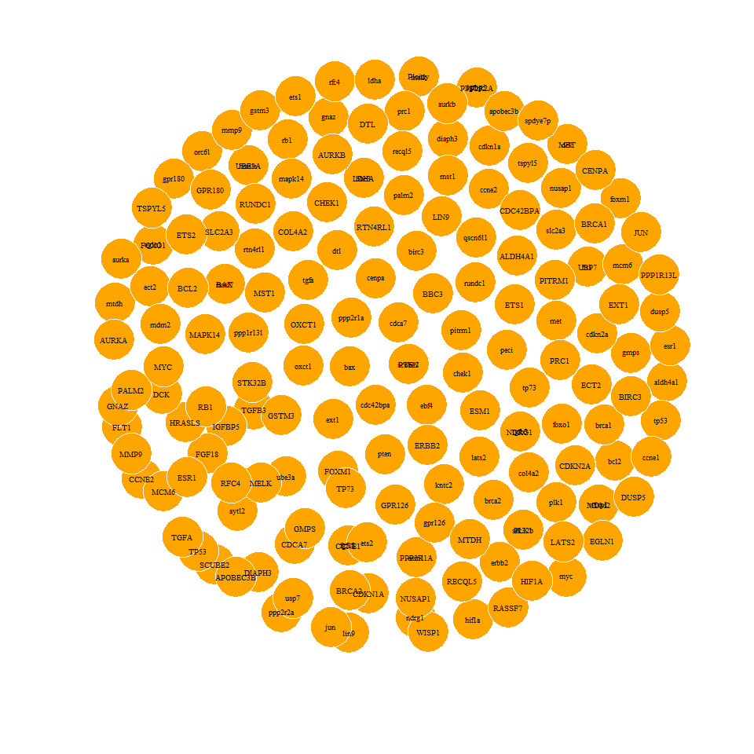

```r
### affichage du graphe (net) obtenu après application de pc et sans isolation
plot(graph_pc_001, edge.arrow.size = .3,
     edge.color = "orange", vertex.color = "orange",
     vertex.frame.color ="#FFFFFF",
     vertex.label.color = "black", vertex.label.cex = .6,
     vertex.label = colnames(cosmicCancer_data),
     layout = layout.fruchterman.reingold)
```

```r
Isolated = which(igraph::degree(graph_pc_001)==0)
graph_pc_I_001 = delete.vertices(graph_pc_001, Isolated)
```

```r
library(qgraph)
e <- get.edgelist(graph_pc_I_001,names=FALSE)
l <- qgraph.layout.fruchtermanreingold(e,vcount=vcount(graph_pc_I_001),
                                      area=8*(vcount(graph_pc_I_001)^2),repulse.rad=(vcount(graph_pc_I_001)^3.1))

colors = rep("cyan3", length(V(graph_pc_I_001)))
colors[names(V(graph_pc_I_001)) == tolower(names(V(graph_pc_I_001)))] = "chartreuse3"
colors[names(V(graph_pc_I_001)) == "Ploidy"] = "brown3"
```

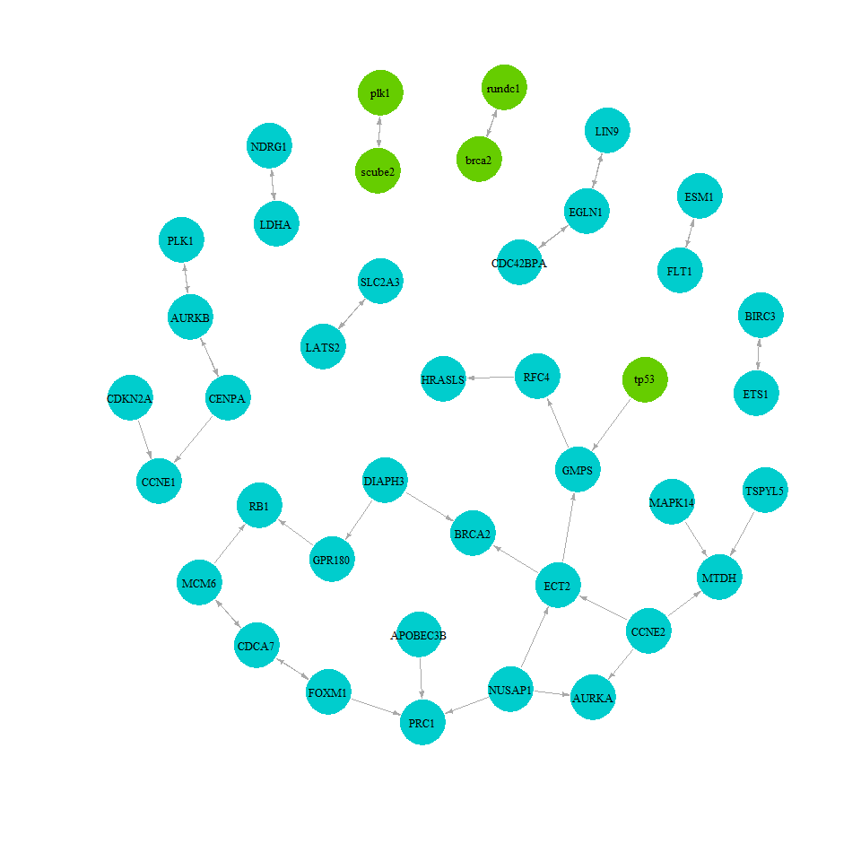

```r
### affichage du graphe (net) obtenu après application de pc et sans isolation
plot(graph_pc_I_001,
     vertex.color=colors,
     edge.arrow.size = .4,
     vertex.frame.color ="#ffffff",
     vertex.label.color = "black", vertex.label.cex = .8,
     layout =l)
```

Nous remaqrquons que le noeud Plody ne figure pas dans ce graphe.

- Alpha = 0.02

```r
data_pc=data.matrix(dataCleaned)
data_pc=data_pc-1
nlevels=apply(data_pc,2,function(x) length(attr(as.factor(x), "levels")))
suffStat=list(dm = data_pc, nlev=nlevels, adaptDF = FALSE)
```

```r
pc_model_05 <- pc(suffStat, indepTest=disCItest, alpha=0.02, labels=colnames(data_pc))
```

```r
pc_model_02 = pc_model_05
pc_model_02
```

```
Object of class 'pcAlgo', from Call:
pc(suffStat = suffStat, indepTest = disCItest, alpha = 0.02,
    labels = colnames(data_pc))
Number of undirected edges:  18
Number of directed edges:    52
Total number of edges:       70
```

Ce cas contient plus d’edge que les deux autres cas précédents (avec alpha = 0.01 et alpha = 0.001)

```r
pc_02<-as.bn(pc_model_02, check.cycles = FALSE)
adj_pc_02<-amat(pc_02)
graph_pc_02 = graph_from_adjacency_matrix(adj_pc_02)
```

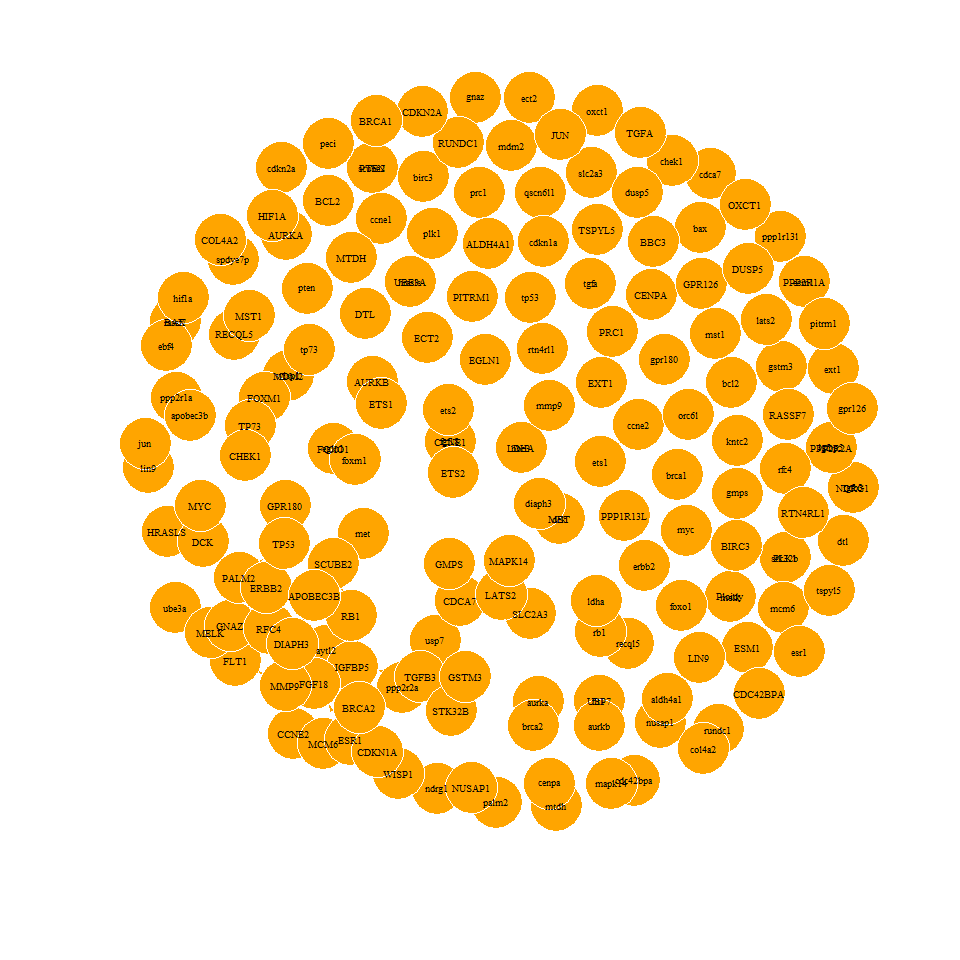

```r
### affichage du graphe (net) obtenu après application de pc et sans isolation
plot(graph_pc_02, edge.arrow.size = .3,
     edge.color = "orange", vertex.color = "orange",
     vertex.frame.color ="#FFFFFF",
     vertex.label.color = "black", vertex.label.cex = .6,
     vertex.label = colnames(cosmicCancer_data),
     layout = layout.fruchterman.reingold)
```

```r
Isolated = which(igraph::degree(graph_pc_02)==0)
graph_pc_I_02 = delete.vertices(graph_pc_02, Isolated)
```

```r
library(qgraph)
e <- get.edgelist(graph_pc_I_02,names=FALSE)
l <- qgraph.layout.fruchtermanreingold(e,vcount=vcount(graph_pc_I_02),
                                      area=8*(vcount(graph_pc_I_02)^2),repulse.rad=(vcount(graph_pc_I_02)^3.1))

colors = rep("cyan3", length(V(graph_pc_I_02)))
colors[names(V(graph_pc_I_02)) == tolower(names(V(graph_pc_I_02)))] = "chartreuse3"
colors[names(V(graph_pc_I_02)) == "Ploidy"] = "brown3"
```

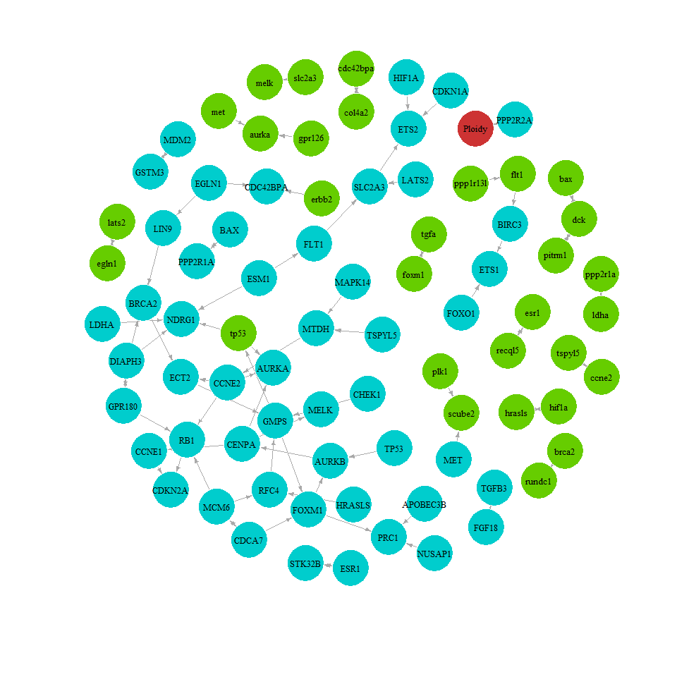

```r
### affichage du graphe (net) obtenu après application de pc et sans isolation
plot(graph_pc_I_02,
     vertex.color=colors,
     edge.arrow.size = .4,
     vertex.frame.color ="#ffffff",
     vertex.label.color = "black", vertex.label.cex = .8,
     layout =l)
```

## Q6

### alpha = 0.01

```r
list=list()
#On récupere la liste des lowercase avec un compteur=0
for(node in names(V(graph_pc_I))) {
    if (node == tolower(node)) { list[node]=0 }
}

#A chaque fois qu'on detecte une relation avec un uppercase on incrémente le compteur
for(i in 1:nrow(get.edgelist(graph_pc_I))) {
    r <- get.edgelist(graph_pc_I)[i,]
    if (r[1] == toupper(r[1]) & r[2] == tolower(r[2])) { list[r[2]]=list[[r[2]]]+1}
    if (r[2] == toupper(r[2]) & r[1] == tolower(r[1])) { list[r[1]]=list[[r[1]]]+1}
}

l<-sort(unlist(list), decreasing=T)
l
```

```
    tp53     ect2    egln1   hrasls      dck   pitrm1    ccne2   tspyl5   rundc1   recql5 cdc42bpa    foxm1     esr1    lats2    brca2     tgfa    hif1a
       3        1        0        0        0        0        0        0        0        0        0        0        0        0        0        0        0
```

- Nous remarquons que tp53 et ect2 sont liées aux variables de gene expression.
- Nous constatons aussi que tp53 est celle qui a le plus de liaisons aux variables de gene expression.

```r
list=list()
#On récupere la liste des lowercase avec un compteur=0
for(node in names(V(graph_pc_I))) {
    if (node == tolower(node)) { list[node]=0 }
}

#A chaque fois qu'on detecte une relation avec un uppercase on incrémente le compteur
for(i in 1:nrow(get.edgelist(graph_pc_I))) {
    r <- get.edgelist(graph_pc_I)[i,]
    if (r[1] == "Ploidy" & r[2] == tolower(r[2])) { list[r[2]]=list[[r[2]]]+1}
    if (r[2] == "Ploidy" & r[1] == tolower(r[1])) { list[r[1]]=list[[r[1]]]+1}
}

l<-sort(unlist(list), decreasing=T)
l
```

```
    tp53    egln1   hrasls      dck   pitrm1    ccne2     ect2   tspyl5   rundc1   recql5 cdc42bpa    foxm1     esr1    lats2    brca2     tgfa    hif1a
       1        0        0        0        0        0        0        0        0        0        0        0        0        0        0        0        0
```

Pour les Noeuds en miniscule, il ya que la variable tp53 qui est liée à Plody.

- Les hubs

```r
#Les hubs
sort(hub_score(graph_pc_I)$vector, decreasing = TRUE)[1:10]
```

```
     tp53     CCNE2     CENPA    NUSAP1    DIAPH3      ESM1      LDHA      ECT2      RFC4   PPP2R2A
1.0000000 0.5441412 0.4843813 0.4327383 0.4193660 0.3513923 0.2911834 0.1968021 0.1968021 0.1644400
```

- Les top 10 noeuds en fonction de la mesure de la centralité d’interdépendance :

```r
sort(betweenness(graph_pc_I), decreasing = TRUE)[1:10]
```

```
  PRC1 DIAPH3   GMPS  FOXM1   ECT2  BRCA2 GPR180    RB1   RFC4   LIN9
    93     88     83     76     52     46     28     17     15     11
```

### alpha = 0.001

```r
list=list()
#On récupere la liste des lowercase avec un compteur=0
for(node in names(V(graph_pc_I_001))) {
    if (node == tolower(node)) { list[node]=0 }
}

#A chaque fois qu'on detecte une relation avec un uppercase on incrémente le compteur
for(i in 1:nrow(get.edgelist(graph_pc_I_001))) {
    r <- get.edgelist(graph_pc_I_001)[i,]
    if (r[1] == toupper(r[1]) & r[2] == tolower(r[2])) { list[r[2]]=list[[r[2]]]+1}
    if (r[2] == toupper(r[2]) & r[1] == tolower(r[1])) { list[r[1]]=list[[r[1]]]+1}
}

l<-sort(unlist(list), decreasing=T)
l
```

```
  tp53 scube2 rundc1  brca2   plk1
     1      0      0      0      0
```

Nous remaqruons qu’il y a uniquemen le noeud tp53 qui est liée aux variables gene.

```r
list=list()
#On récupere la liste des lowercase avec un compteur=0
for(node in names(V(graph_pc_I_001))) {
    if (node == tolower(node)) { list[node]=0 }
}

#A chaque fois qu'on detecte une relation avec un uppercase on incrémente le compteur
for(i in 1:nrow(get.edgelist(graph_pc_I_001))) {
    r <- get.edgelist(graph_pc_I_001)[i,]
    if (r[1] == "Ploidy" & r[2] == tolower(r[2])) { list[r[2]]=list[[r[2]]]+1}
    if (r[2] == "Ploidy" & r[1] == tolower(r[1])) { list[r[1]]=list[[r[1]]]+1}
}

l<-sort(unlist(list), decreasing=T)
l
```

```
scube2 rundc1   tp53  brca2   plk1
     0      0      0      0      0
```

Pour les Noeuds en miniscule, il ya aucun qui est liée à Plody car Plody ne figure même pas dans les noeuds du graphes.

```r
#Les hubs
sort(hub_score(graph_pc_I_001)$vector, decreasing = TRUE)[1:10]
```

```
      NUSAP1        CCNE2        FOXM1     APOBEC3B       TSPYL5       MAPK14         MCM6       GPR180         MTDH         PRC1
1.000000e+00 9.657342e-01 3.907017e-01 3.008228e-01 2.665570e-01 2.665570e-01 1.146869e-01 2.480792e-02 4.238212e-17 4.238212e-17
```

- Les top 10 noeuds en fonction de la mesure de la centralité d’interdépendance :

```r
sort(betweenness(graph_pc_I_001), decreasing = TRUE)[1:10]
```

```
  ECT2   GMPS   RFC4  CDCA7  AURKB  EGLN1  CENPA   MCM6  FOXM1 GPR180
     8      8      5      4      3      2      2      2      2      1
```

### alpha = 0.02

```r
list=list()
#On récupere la liste des lowercase avec un compteur=0
for(node in names(V(graph_pc_I_02))) {
    if (node == tolower(node)) { list[node]=0 }
}

#A chaque fois qu'on detecte une relation avec un uppercase on incrémente le compteur
for(i in 1:nrow(get.edgelist(graph_pc_I_02))) {
    r <- get.edgelist(graph_pc_I_02)[i,]
    if (r[1] == toupper(r[1]) & r[2] == tolower(r[2])) { list[r[2]]=list[[r[2]]]+1}
    if (r[2] == toupper(r[2]) & r[1] == tolower(r[1])) { list[r[1]]=list[[r[1]]]+1}
}

l<-sort(unlist(list), decreasing=T)
l
```

```
    tp53   scube2     flt1    erbb2    egln1   hrasls      dck     melk   pitrm1    ccne2   tspyl5   rundc1   recql5   col4a2   gpr126 cdc42bpa   slc2a3    foxm1
       3        1        1        1        0        0        0        0        0        0        0        0        0        0        0        0        0        0
    esr1    lats2    aurka    brca2 ppp1r13l     tgfa    hif1a     ldha  ppp2r1a     plk1      bax      met
       0        0        0        0        0        0        0        0        0        0        0        0
```

```r
list=list()
#On récupere la liste des lowercase avec un compteur=0
for(node in names(V(graph_pc_I_02))) {
    if (node == tolower(node)) { list[node]=0 }
}

#A chaque fois qu'on detecte une relation avec un uppercase on incrémente le compteur
for(i in 1:nrow(get.edgelist(graph_pc_I_02))) {
    r <- get.edgelist(graph_pc_I_02)[i,]
    if (r[1] == "Ploidy" & r[2] == tolower(r[2])) { list[r[2]]=list[[r[2]]]+1}
    if (r[2] == "Ploidy" & r[1] == tolower(r[1])) { list[r[1]]=list[[r[1]]]+1}
}

l<-sort(unlist(list), decreasing=T)
l
```

```
   egln1   scube2     flt1   hrasls      dck     melk   pitrm1    ccne2   tspyl5   rundc1   recql5   col4a2   gpr126 cdc42bpa   slc2a3    foxm1    erbb2     esr1
       0        0        0        0        0        0        0        0        0        0        0        0        0        0        0        0        0        0
    tp53    lats2    aurka    brca2 ppp1r13l     tgfa    hif1a     ldha  ppp2r1a     plk1      bax      met
       0        0        0        0        0        0        0        0        0        0        0        0
```

Pour les Noeuds en miniscule, il y a aucun qui est liée à Plody.

```r
#Les hubs
sort(hub_score(graph_pc_I_02)$vector, decreasing = TRUE)[1:10]
```

```
    CCNE2      tp53    DIAPH3     CENPA      ESM1      MCM6      LDHA    GPR180     BRCA2      LIN9
1.0000000 0.9260523 0.7659294 0.6919817 0.5723318 0.5473181 0.4733704 0.4089771 0.2090569 0.1601229
```

- Les top 10 noeuds en fonction de la mesure de la centralité d’interdépendance :

```r
sort(betweenness(graph_pc_I_02), decreasing = TRUE)[1:10]
```

```
 GMPS FOXM1  ECT2 AURKB CENPA BRCA2 CCNE2  MTDH  tp53  RFC4
  123    89    87    67    53    44    39    28    25    18
```